# Notebook

### KBO 리그 데이터 분석 (feat. plotly) - 선수들의 타율, 나이 및 연봉 분석

### 데이터 출처

수집 일자 : 2020/07/16

2020 선수 기록 데이터 - [statiz_stat](http://www.statiz.co.kr/stat.php?opt=0&sopt=0&re=0&ys=2020&ye=2020&se=0&te=&tm=&ty=0&qu=auto&po=0&as=&ae=&hi=&un=&pl=&da=1&o1=WAR_ALL_ADJ&o2=TPA&de=1&lr=0&tr=&cv=&ml=1&sn=30&si=&cn=)  
2020 선수 연봉 데이터 - [statiz_salary](http://www.statiz.co.kr/salary.php)

### Contents

python의 시각화 라이브러리중 하나인 'plotly'와 statiz에서 제공하는 야구데이터를 활용해 EDA(데이터를 탐색하고 가치를 창출하는 것)과정을 진행한다. 그리고 간단한 회귀분석을 통해 데이터를 이용한 예측에 대해 살펴볼 것이다.  
또한 야구데이터에는 타율, 볼넷, 홈런, 출루율, 장타율, OPS, WAR 등 많은 종류의 항목들이 있고 개별 항목들은 모두 탐색해볼 가치가 있으나 이번 시간에는 대중적으로 잘 알려진 요소인 '타율'과 '홈런' 선수 순위, 그리고 이들과 '나이', '연봉', '홈런' 등 과의 관계에 대해서 중점적으로 분석할 예정이다.

### 분석 소재

**타율**

1. 2020년도 타율, 홈런 top10 선수는?
2. 홈런과 타율에는 관계가 있을까? 나이와 타율은?

**연봉**

1. 선수에게 연봉을 가장 많이 주는 구단은?
2. 나이, 타율 등 연봉과 관계가 있는 요소는?

### Keywords

타율 : (전체 안타 횟수)/(타수)

*타수는 타석과 다른데, 타석은 배팅박스에 들어간 횟수(배트를 들고 경기에 임한 횟수)를 뜻하며 타수는 타석에서 볼넷, 사구, 희생플라이 등을 제외한 횟수를 뜻한다.

### Missing data

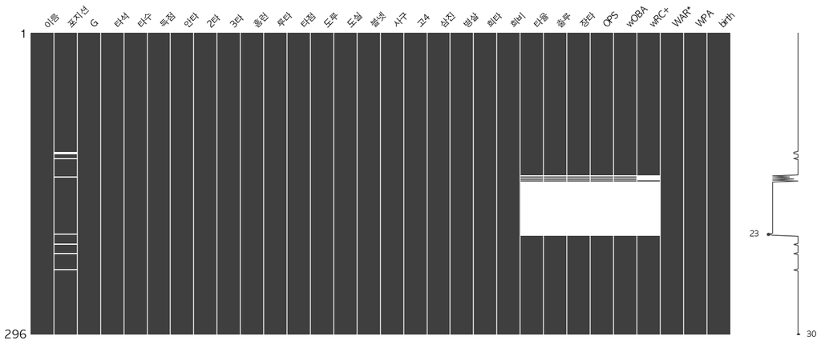

데이터의 중간 부분에(타율~wRC+ 열에서) 결측치(흰 부분)가 존재함을 알 수 있다.  
그래서 먼저 타율과 출루가 빈 값인 데이터를 모아서 데이터의 특징을 확인해 보자.

```
Index(['이름', '포지션', 'G', '타석', '타수', '득점', '안타', '2타', '3타', '홈런', '루타', '타점',
       '도루', '도실', '볼넷', '사구', '고4', '삼진', '병살', '희타', '희비', '타율', '출루', '장타',
       'OPS', 'wOBA', 'wRC+', 'WAR*', 'WPA', 'birth'],
      dtype='object')
```

|  | G | 타석 | 타수 | 득점 | 안타 | 2타 | 3타 | 홈런 | 루타 | 타점 | ... | 희비 | 타율 | 출루 | 장타 | OPS | wOBA | wRC+ | WAR* | WPA | 나이 |
| --- | --- | --- | --- | --- | --- | --- | --- | --- | --- | --- | --- | --- | --- | --- | --- | --- | --- | --- | --- | --- | --- |
| count | 296.000000 | 296.000000 | 296.000000 | 296.000000 | 296.000000 | 296.000000 | 296.000000 | 296.000000 | 296.000000 | 296.000000 | ... | 296.000000 | 240.000000 | 240.000000 | 240.000000 | 240.000000 | 240.000000 | 238.000000 | 296.000000 | 296.000000 | 296.000000 |
| mean | 25.543919 | 79.202703 | 69.959459 | 10.557432 | 19.219595 | 3.361486 | 0.270270 | 2.013514 | 29.162162 | 10.000000 | ... | 0.706081 | 0.242479 | 0.308225 | 0.348592 | 0.656854 | 0.299100 | 74.146639 | 0.299054 | 0.109696 | 28.229730 |
| std | 21.209482 | 86.002441 | 75.444884 | 13.123278 | 22.909455 | 4.755842 | 0.718705 | 3.569146 | 36.937337 | 13.403516 | ... | 1.234297 | 0.118681 | 0.125659 | 0.191132 | 0.301185 | 0.129926 | 83.455879 | 0.723734 | 0.654992 | 4.908788 |
| min | 1.000000 | 0.000000 | 0.000000 | 0.000000 | 0.000000 | 0.000000 | 0.000000 | 0.000000 | 0.000000 | 0.000000 | ... | 0.000000 | 0.000000 | 0.000000 | 0.000000 | 0.000000 | 0.000000 | -123.800000 | -1.020000 | -1.410000 | 19.000000 |
| 25% | 3.000000 | 4.750000 | 4.000000 | 0.000000 | 0.000000 | 0.000000 | 0.000000 | 0.000000 | 0.000000 | 0.000000 | ... | 0.000000 | 0.198500 | 0.252750 | 0.250000 | 0.515500 | 0.242000 | 35.975000 | -0.070000 | -0.140000 | 25.000000 |
| 50% | 20.500000 | 43.000000 | 38.500000 | 5.000000 | 9.000000 | 1.000000 | 0.000000 | 0.000000 | 12.500000 | 4.000000 | ... | 0.000000 | 0.250000 | 0.324000 | 0.357000 | 0.691500 | 0.317000 | 83.800000 | 0.000000 | 0.000000 | 28.000000 |
| 75% | 46.000000 | 142.000000 | 129.000000 | 17.000000 | 32.000000 | 5.000000 | 0.000000 | 3.000000 | 48.250000 | 15.000000 | ... | 1.000000 | 0.294500 | 0.372000 | 0.451000 | 0.820500 | 0.367250 | 117.125000 | 0.367500 | 0.137500 | 31.000000 |
| max | 62.000000 | 281.000000 | 246.000000 | 55.000000 | 92.000000 | 23.000000 | 5.000000 | 21.000000 | 174.000000 | 56.000000 | ... | 8.000000 | 1.000000 | 1.000000 | 2.000000 | 3.000000 | 1.276000 | 707.100000 | 3.970000 | 2.890000 | 41.000000 |

8 rows × 28 columns

|  | 이름 | 포지션 | G | 타석 | 타수 | 득점 | 안타 | 2타 | 3타 | 홈런 | ... | 희비 | 타율 | 출루 | 장타 | OPS | wOBA | wRC+ | WAR* | WPA | birth |
| --- | --- | --- | --- | --- | --- | --- | --- | --- | --- | --- | --- | --- | --- | --- | --- | --- | --- | --- | --- | --- | --- |
| 140 | 홍종표 | 2B | 2 | 0 | 0 | 1 | 0 | 0 | 0 | 0 | ... | 0 | NaN | NaN | NaN | NaN | NaN | NaN | 0.0 | 0.0 | 2000-05-02 |
| 142 | 현원회 | C | 1 | 0 | 0 | 0 | 0 | 0 | 0 | 0 | ... | 0 | NaN | NaN | NaN | NaN | NaN | NaN | 0.0 | 0.0 | 2001-07-08 |
| 144 | 최용제 | C | 1 | 0 | 0 | 0 | 0 | 0 | 0 | 0 | ... | 0 | NaN | NaN | NaN | NaN | NaN | NaN | 0.0 | 0.0 | 1991-07-12 |
| 146 | 박지규 | 2B | 1 | 0 | 0 | 0 | 0 | 0 | 0 | 0 | ... | 0 | NaN | NaN | NaN | NaN | NaN | NaN | 0.0 | 0.0 | 1991-10-12 |
| 147 | 오현택 | P | 1 | 0 | 0 | 0 | 0 | 0 | 0 | 0 | ... | 0 | NaN | NaN | NaN | NaN | NaN | NaN | 0.0 | 0.0 | 1994-09-04 |

5 rows × 30 columns

|  | G | 타석 | 타수 | 득점 | 안타 | 2타 | 3타 | 홈런 | 루타 | 타점 | ... | 희타 | 희비 | 타율 | 출루 | 장타 | OPS | wOBA | wRC+ | WAR* | WPA |
| --- | --- | --- | --- | --- | --- | --- | --- | --- | --- | --- | --- | --- | --- | --- | --- | --- | --- | --- | --- | --- | --- |
| count | 56.000000 | 56.0 | 56.0 | 56.000000 | 56.0 | 56.0 | 56.0 | 56.0 | 56.0 | 56.0 | ... | 56.0 | 56.0 | 0.0 | 0.0 | 0.0 | 0.0 | 0.0 | 0.0 | 56.0 | 56.000000 |
| mean | 1.339286 | 0.0 | 0.0 | 0.017857 | 0.0 | 0.0 | 0.0 | 0.0 | 0.0 | 0.0 | ... | 0.0 | 0.0 | NaN | NaN | NaN | NaN | NaN | NaN | 0.0 | 0.000357 |
| std | 0.745332 | 0.0 | 0.0 | 0.133631 | 0.0 | 0.0 | 0.0 | 0.0 | 0.0 | 0.0 | ... | 0.0 | 0.0 | NaN | NaN | NaN | NaN | NaN | NaN | 0.0 | 0.002673 |
| min | 1.000000 | 0.0 | 0.0 | 0.000000 | 0.0 | 0.0 | 0.0 | 0.0 | 0.0 | 0.0 | ... | 0.0 | 0.0 | NaN | NaN | NaN | NaN | NaN | NaN | 0.0 | 0.000000 |
| 25% | 1.000000 | 0.0 | 0.0 | 0.000000 | 0.0 | 0.0 | 0.0 | 0.0 | 0.0 | 0.0 | ... | 0.0 | 0.0 | NaN | NaN | NaN | NaN | NaN | NaN | 0.0 | 0.000000 |
| 50% | 1.000000 | 0.0 | 0.0 | 0.000000 | 0.0 | 0.0 | 0.0 | 0.0 | 0.0 | 0.0 | ... | 0.0 | 0.0 | NaN | NaN | NaN | NaN | NaN | NaN | 0.0 | 0.000000 |
| 75% | 1.000000 | 0.0 | 0.0 | 0.000000 | 0.0 | 0.0 | 0.0 | 0.0 | 0.0 | 0.0 | ... | 0.0 | 0.0 | NaN | NaN | NaN | NaN | NaN | NaN | 0.0 | 0.000000 |
| max | 5.000000 | 0.0 | 0.0 | 1.000000 | 0.0 | 0.0 | 0.0 | 0.0 | 0.0 | 0.0 | ... | 0.0 | 0.0 | NaN | NaN | NaN | NaN | NaN | NaN | 0.0 | 0.020000 |

8 rows × 27 columns

요약통계량을 확인해보니 타율이 빈 값인 데이터들(총 56개)은 공통적으로 타석과 타수가 0이었음을 알 수 있다(min, max가 모두 0).  
당연히 타석에 서지않았으니 타율을 계산할 수가 없어 NaN(결측치)로 처리된 것이다.

# 타율

[interactive chart not shown]

타율의 box plot을 살펴보면 매우 높은 값이나 낮은 값을 가진 선수들의 공통점은 타석수가 적었다는 것이다. 이는 타석수가 적을수록 값의 분산이 커 위와같은 이상치가 발생하기 쉽기 때문이며 한국야구위원회에서는 타율, 장타율 등의 순위를 매길 때 **규정타석** 이상 타석에 선 선수만이 공식적인 순위에 기록된다. 따라서 우리도 타율과 관련된 분석을 할 때는 규정타석 이상 타석에 선 선수만을 대상으로 하자.  
규정타석은 그 타자의 소속팀이 치른 전체 경기 수의 3.1을 곱한 값에서 소수점을 버린 값으로 규정되며 데이터 수집일인 7월16일 기준 각 팀은 평균 61경기를 뛰었기 때문에 분석 대상을 타석에 189회 이상 선 선수들을 대상으로 하자 (61*3.1=189.1)

## 1. 2020년도 타율, 홈런 top10은?

7월 16일(목) 기준

- Sort values
- Bar plot

총 51명의 kbo 선수들을 대상으로 함

```
51
```

[interactive chart not shown]

로하스가 7월 16일 기준 타율과 홈런횟수 모두 1위를 기록했다.

## 2. 홈런과 타율, 나이와 타율은 관계가 있을까?

- Scatter plot

[interactive chart not shown]

|  | 홈런 | 타율 | 나이 |
| --- | --- | --- | --- |
| 홈런 | 1.000000 | 0.304061 | 0.064195 |
| 타율 | 0.304061 | 1.000000 | 0.055960 |
| 나이 | 0.064195 | 0.055960 | 1.000000 |

scatter plot과 상관계수를 통해 홈런과 타율은 어느정도 양의 관계를 보임을 알 수 있고, 나이와 타율은 관계가 크게 없음을 알 수 있다.

# 연봉

### 2020년 기준 연봉 데이터

단위 : 만(원)

|  | 선수 | 연도 | 팀 | 연봉 |
| --- | --- | --- | --- | --- |
| 0 | 양현종 | 2020 | KIA | 230,000 |
| 1 | 최형우 | 2020 | KIA | 150,000 |
| 2 | 가뇽 | 2020 | KIA | 65,000 |
| 3 | 나지완 | 2020 | KIA | 60,000 |
| 4 | 터커 | 2020 | KIA | 55,000 |

```
count       681.000000
mean      14123.788546
std       27227.430336
min        2700.000000
25%        2700.000000
50%        4000.000000
75%       11000.000000
max      250000.000000
Name: 연봉, dtype: float64
```

[interactive chart not shown]

총 681명의 야구선수 연봉 분포를 보면 연봉은 낮은금액에 치우쳐 있음을 확인할 수 있다.(상위 25%가 1.1억)

## 3. 선수에게 연봉을 가장 많이 주는 구단은?

총 681명의 선수들 대상

- Group by
- Bar plot
- Pie chart

### 팀별 연봉 합

[interactive chart not shown]

팀별 선수에게 지급하는 연봉 총액의 경우 LG가 약 110억 정도로 가장 많았고, kt가 약 79억 정도로 가장 적었다.

[interactive chart not shown]

- 롯데의 이대호가 25억으로 가장 많은 연봉을 받음을 알 수 있다.
- 선수가 받는 평균 연봉은 NC가 가장 높았다.

|  | 선수 | 연도 | 팀 | 연봉 |
| --- | --- | --- | --- | --- |
| 137 | 김재호 | 2020 | 두산 | 65000 |
| 138 | 김재환 | 2020 | 두산 | 65000 |
| 412 | 서폴드 | 2020 | 한화 | 90000 |
| 595 | 황재균 | 2020 | kt | 120000 |
| 73 | 강민호 | 2020 | 삼성 | 125000 |
| 204 | 이재원 | 2020 | SK | 130000 |
| 273 | 김현수 | 2020 | LG | 130000 |
| 472 | 박병호 | 2020 | 키움 | 200000 |
| 529 | 양의지 | 2020 | NC | 200000 |
| 0 | 양현종 | 2020 | KIA | 230000 |
| 342 | 이대호 | 2020 | 롯데 | 250000 |

팀별 연봉 수령액 1위 선수의 연봉을 보면 롯데의 이대호가 25억으로 가장 높은 금액이었고, 두산의 김재호, 김재환이 6.5억으로 팀내 1위지만 전체에서는 최하위를 차지했다.

[interactive chart not shown]

## 4. 나이, 타율 등 연봉과 관계가 있는 요소는?

규정타격 이상 선수들을 대상

- Merge
- Scatter matrix

|  | 이름 | 포지션 | 홈런 | 타율 | 나이 | 연봉 |
| --- | --- | --- | --- | --- | --- | --- |
| 0 | 로하스 | RF | 21 | 0.380 | 30 | 80000 |
| 1 | 이정후 | RF | 10 | 0.363 | 22 | 39000 |
| 2 | 김하성 | SS | 14 | 0.280 | 25 | 55000 |
| 3 | 페르난데스 | DH | 11 | 0.370 | 32 | 40000 |
| 4 | 알테어 | CF | 16 | 0.306 | 29 | 80000 |

|  | 이름 | 나이 | 연봉 |
| --- | --- | --- | --- |
| 0 | 로하스 | 30 | 80000 |
| 1 | 이정후 | 22 | 39000 |
| 2 | 김하성 | 25 | 55000 |
| 3 | 페르난데스 | 32 | 40000 |
| 4 | 알테어 | 29 | 80000 |

[interactive chart not shown]

타율과 홈런은 이전에 확인했듯이 어느정도 관계가 있었고, 나이와 연봉 또한 양의 상관관계가 있음을 확인할 수 있다.

### 간단한 예측

```
LinearRegression(copy_X=True, fit_intercept=True, n_jobs=None, normalize=False)
```

[interactive chart not shown]

마지막으로 선수별 타율(x)과 연봉(y)과의 관계를 선형회귀모형을 이용해 적합해보았다.(빨간 선이 회귀직선)  
두 값은 뚜렷한 선형관계를 보이지않기 때문에 단순 선형회귀를 이용했을때 좋은 결과를 낼 수는 없었다.  
좀더 나은 예측을 위해서는 타율 뿐만 아니라 여러 다른 적절히 요소들을 추가하고, y(연봉)값의 이상치를 제거하는 등 여러 과정이 필요할 것이다.